# Impulsive Reaction Time between Casual and Top 150 Esports Players

Kiwi, Isabella

Kinesiology Department at CSUMB, Marine Science Department at CSUMB

## Motivation

- In the growing Esports industry, competitive Super Smash Bros Ultimate (SSBU) players require quick reactions and timely responses to stimuli.
- Research into the field of Esports in relation to cognition is still emerging and understanding how it impacts cognitive function may be applicable to populations seeing a decline in cognition.
- Professional Esports athletes practice 5-10 hours per day, nearly consistent with traditional sports and more than their casual counterpart (Emara et al. 2020).
- Populations that may not be able to participate in traditional sports may still benefit from gaming, as seen in improving older elderly cognitive time for switching between tasks (Basak et al. 2008).

## Background

- Esports as a field requires accuracy where one thousandth of a second can determine whether a team or person wins. Skills like quick reaction times increase the chances of succeeding in faster paced video games which require these skills (Ersin at al. 2022).
- A recent study (Ziv et. al., 2022) found evidence that asking participants about their gaming status (gamer or non-gamer) positively affected performance for gamers and had an adverse effect on non-gamers in cognitive motor task performance.
- We want to further that evidence and see if the degree of competitiveness elicits a further positive effect on stimulated reaction time.

[figure not shown]

GX3 February 2026, Winners Semi-finals

# Methods

## Methods - Data Collection

- Participant collection included visiting local Monterey, San Jose, and CSUMB SSBU tournaments to ask people to join, and other non-random methods of obtaining participants.
- Conducted computerized practice assessment to get them accustomed to the software and then the actual congitive test to collect data on impulsivity via the GO/NoGO test
- Casual SSBU players (play at least 4 hours per week of the game), Elite SSBU players (ranked top 150 in the world)

## Methods - Variable Creation

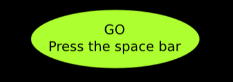

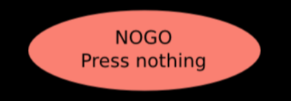

## Methods - Analytic Methods

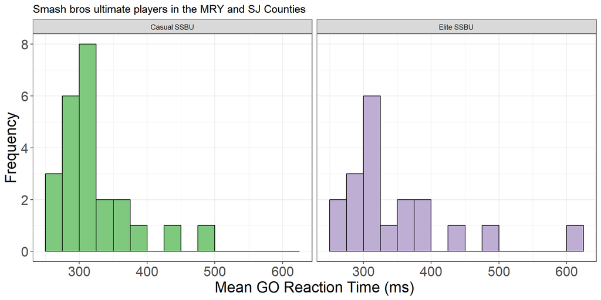

| Game | median | IQR | n |
| --- | --- | --- | --- |
| Casual SSBU | 315.275 | 52.7875 | 24 |
| Elite SSBU | 322.750 | 82.4250 | 19 |

## Methods - Decision

*Why did you use nonparametric methods?*  
- Right skew and outliers within the small sample sized groups ($n_{casual}$ = 24, $n_{elite}$ = 19), median/ shift is the more appropriate measure of center.  
- T-Distribution and randomized equivalents would not be appropriate to measure difference in true medians/ true shift.  
- We are planning on running a Wilcoxon Rank Sum Test (WRST) since we have numeric, independent data, roughly equal variance and two population distributions of the same shape.

# Results

## Summary Graphics

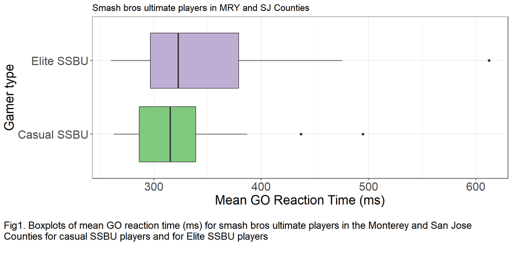

# Non-parametric Analysis

## Wilcoxon Rank Sum test

```
    Wilcoxon rank sum test with continuity correction

data:  casual and elite
W = 181.5, p-value = 0.8748
alternative hypothesis: true location shift is greater than 0
```

- 0.8748 probability of observing W = 181.5 or greater, assuming the true shift of Mean GO Reaction Time (ms) in the casual and elite Smash bros ultimate players in the MRY and SJ Counties is zero.

## Confidence Interval

- Confidence Interval : (-48.10003, 13.95001)
- Include negative, zero and positive numbers.
- True shift could be less than zero, zero, or greater than zero.
- Cannot make a clear conclusion on the true shift of Mean GO Reaction Time (ms) in the casual and elite Smash bros ultimate players in the MRY and SJ Counties

# Summary

## Future Work

Include a random sample to generalize to the larger populations

Delve into the other variables not included such as:  
- Other game types  
- Other measures of reaction time  
- Controller specific reaction speed

## References

- Basak, Chandramallika, et al. “Can Training in a Real-Time Strategy Video Game Attenuate Cognitive Decline in Older Adults?” Psychology and Aging, vol. 23, no. 4, Dec. 2008, pp. 765–77. PubMed, https://doi.org/10.1037/a0013494.
- Basak, Chandramallika, et al. “Can Training in a Real-Time Strategy Video Game Attenuate Cognitive Decline in Older Adults?” Psychology and Aging, vol. 23, no. 4, Dec. 2008, pp. 765–77. PubMed, https://doi.org/10.1037/a0013494.
- Emara, Ahmed K., et al. (2020) “Gamer’s Health Guide: Optimizing Performance, Recognizing Hazards, and Promoting Wellness in Esports.” Current Sports Medicine Reports, vol. 19, no. 12, Dec. 2020, pp. 537–45. DOI.org (Crossref), https://doi.org/10.1249/JSR.0000000000000787.
- Ersin, A., Tezeren, H., Pekyavas, N., Asal, B., Atabey, A., Diri, A., & Gonen, I. (2022). The relationship between reaction time and gaming time in E-sports players. Kinesiology, 54(1), 36-42.
- Ziv, G., Lidor, R. & Levin, O. Reaction time and working memory in gamers and non-gamers. Sci Rep 12, 6798 (2022). https://doi.org/10.1038/s41598-022-10986-3